# getting TCGA COAD Methylation and Expression data from cBioportal

# Introduction

The analysis of L shaped genes performed elsewhere (“Informe_v12.2_L-Shape_Selection_Pipeline.Rnw”) has used data obtained from TCGA and provided by the researcher.

These data have shown a surprisingly low number of L-shaped genes when they have been processed with the *heuristic* algorithm. Before reviewing the algorithm or its parameters we have wanted to check if the data have been properly processed.

With this aim in mind we have obtained the data from the cBioportal and processed them in a `reasonable’ way.

```r
source("Rcode/usefulFunctions.R")
```

# Obtaining the data

The datasets have been downloaded from the cBioportal web site and consist of the “tumor-only” data from the Nature 2012 study.

## Expression data

```r
x<- data_expression_merged_median_Zscores <- read.delim("dades/gdac.20160128.cBioportal/coadread_tcga_pub/data_expression_merged_median_Zscores.txt",sep="\t", head = TRUE)
DimMat(x, "Expression data")
```

```
## [1] 17786   225
##
## First rows and columns
##   Entrez_Gene_Id TCGA.A6.2670 TCGA.A6.2672 TCGA.A6.2674 TCGA.A6.2676
## 1           6205      -0.3558       0.9810      -1.2011       0.9000
## 2           9240      -0.4357       1.3534       1.1311       2.7849
## 3           4313       1.9436       0.9944       3.2631      -0.8883
## 4         118611       0.2938      -1.2223      -0.6092      -0.7407
## 5          23051       0.1557       0.2268       2.4051      -1.1417
## 6           2073       1.5886       2.1599       2.5763      -0.1131
##
## Last rows first columns
##       Entrez_Gene_Id TCGA.A6.2670 TCGA.A6.2672 TCGA.A6.2674 TCGA.A6.2676
## 17781    hsa-miR-653       0.3125      -1.4160       0.9391       0.2015
## 17782 hsa-miR-542-3p       0.9243      -0.3159       0.5633      -1.4600
## 17783    hsa-miR-744      -0.5772      -2.4297       0.6828      -1.5683
## 17784   hsa-miR-744*      -0.8994      -1.5494      -0.4266      -0.3811
## 17785   hsa-miR-374b      -0.2753      -1.6204      -0.0505      -1.0873
## 17786    hsa-miR-664       0.6066       0.0449       1.2186      -0.2077
```

The first column contains Entrez identifiers which may be used (if unique) as row names. However it also contains miRNA identifiers (“hsa-*“) showing that the last rows are not gene expression but microRNAs expression values. These are removed from the dataset

```r
sum(duplicated(x$Entrez_Gene_Id))
```

```
## [1] 0
```

```r
rownames(x) <- expresEntrez<- x$Entrez_Gene_Id
if(ncol(x)==225) x<- x[,-1]
miRNAs <- grep("hsa-*", rownames(x))
x <- x[-miRNAs,]
DimMat(x)
```

```
## [1] 17487   224
##
## First rows and columns
##        TCGA.A6.2670 TCGA.A6.2672 TCGA.A6.2674 TCGA.A6.2676 TCGA.A6.2677
## 6205        -0.3558       0.9810      -1.2011       0.9000      -0.1387
## 9240        -0.4357       1.3534       1.1311       2.7849      -0.3527
## 4313         1.9436       0.9944       3.2631      -0.8883      -1.4257
## 118611       0.2938      -1.2223      -0.6092      -0.7407       0.1848
## 23051        0.1557       0.2268       2.4051      -1.1417       0.0739
## 2073         1.5886       2.1599       2.5763      -0.1131      -0.1758
##
## Last rows first columns
##        TCGA.A6.2670 TCGA.A6.2672 TCGA.A6.2674 TCGA.A6.2676 TCGA.A6.2677
## 122042      -1.0768      -1.9185       0.4920      -0.6986       0.6908
## 113791       2.6684       0.5805       0.1631      -1.6714      -0.5716
## 25800       -1.0579       0.3358      -0.4029      -0.7341      -1.2276
## 6633        -0.3276      -0.6036      -0.5753       1.2459       0.0553
## 364          1.8823      -1.5395      -0.1225      -0.4081       2.4561
## 1075         0.4352       0.3916       1.1339       1.1667      -1.0711
```

Entrez identifiers are good for indexing but may be confusing as row names, and they are not informative about the gene. They are converted into HuGO symbols.

```r
require(Homo.sapiens)
anotacs<- select(Homo.sapiens, keys=rownames(x), columns= "SYMBOL", keytype="ENTREZID")
DimMat(anotacs, "Entrez and HuGO identifiers",2)
```

```
## [1] 17487     2
##
## First rows and columns
##   ENTREZID   SYMBOL
## 1     6205    RPS11
## 2     9240    PNMA1
## 3     4313     MMP2
## 4   118611 C10orf90
## 5    23051     ZHX3
## 6     2073    ERCC5
##
## Last rows first columns
##       ENTREZID  SYMBOL
## 17482   122042   RXFP2
## 17483   113791 PIK3IP1
## 17484    25800 SLC39A6
## 17485     6633  SNRPD2
## 17486      364    AQP7
## 17487     1075    CTSC
```

Some Entrezs are not associated with gene symbols.

```r
 head(anotacs[is.na(anotacs[,2]),])
```

```
##      ENTREZID SYMBOL
## 155    389102   <NA>
## 282    117153   <NA>
## 890    442092   <NA>
## 2264    26148   <NA>
## 3505   728404   <NA>
## 3584   641590   <NA>
```

These genes are removed and then the remaining gene symbols (uniquely associated with Entrez Ids) are used as rownames. before doing the assignment NAs are removed from the Symbols list.

```r
Entrez_without_Symbol<- is.na(anotacs[,2])
x<- x[!Entrez_without_Symbol,]
anotacs<- anotacs[!Entrez_without_Symbol,]
rownames(x) <-anotacs[,2]
DimMat(x)
```

```
## [1] 17460   224
##
## First rows and columns
##          TCGA.A6.2670 TCGA.A6.2672 TCGA.A6.2674 TCGA.A6.2676 TCGA.A6.2677
## RPS11         -0.3558       0.9810      -1.2011       0.9000      -0.1387
## PNMA1         -0.4357       1.3534       1.1311       2.7849      -0.3527
## MMP2           1.9436       0.9944       3.2631      -0.8883      -1.4257
## C10orf90       0.2938      -1.2223      -0.6092      -0.7407       0.1848
## ZHX3           0.1557       0.2268       2.4051      -1.1417       0.0739
## ERCC5          1.5886       2.1599       2.5763      -0.1131      -0.1758
##
## Last rows first columns
##         TCGA.A6.2670 TCGA.A6.2672 TCGA.A6.2674 TCGA.A6.2676 TCGA.A6.2677
## RXFP2        -1.0768      -1.9185       0.4920      -0.6986       0.6908
## PIK3IP1       2.6684       0.5805       0.1631      -1.6714      -0.5716
## SLC39A6      -1.0579       0.3358      -0.4029      -0.7341      -1.2276
## SNRPD2       -0.3276      -0.6036      -0.5753       1.2459       0.0553
## AQP7          1.8823      -1.5395      -0.1225      -0.4081       2.4561
## CTSC          0.4352       0.3916       1.1339       1.1667      -1.0711
```

The resulting matrix has many genes with all values set to NA and a few genes with a few NAs. Genes with more than 75% NAs are removed.

```r
quantsNAs_x <- countNAs(x)
table(quantsNAs_x)
```

```
## quantsNAs_x
##   1   2   3   4   5   6 224
## 144  58  23  14   2   2 851
```

```r
maxNAs <- floor(0.75*dim(x)[2])
genes2Remove <- names(quantsNAs_x [quantsNAs_x > maxNAs])
expres2Keep <- x[setdiff(rownames(x),genes2Remove),]
dim(expres2Keep)
```

```
## [1] 16609   224
```

```r
save(expres2Keep, file="TCGA-COAD-expressions0.Rda")
```

## Methylation Data

Methylation data are processed similarly

```r
y <- data_methylation_hm27 <- read.delim("dades/gdac.20160128.cBioportal/coadread_tcga_pub/data_methylation_hm27.txt", sep="\t", head = TRUE)
DimMat(y)
```

```
## [1] 12328   238
##
## First rows and columns
##   Hugo_Symbol Entrez_Gene_Id TCGA.A6.2670 TCGA.A6.2672 TCGA.A6.2674
## 1       MEOX2           4223   0.04982367   0.35746202  0.184220217
## 2       IMPA2           3613   0.01682225   0.01740079  0.013319633
## 3        TTC8         123016   0.01319039   0.01489892  0.008213065
## 4      RNASE4           6038   0.01984625   0.02053177  0.009412528
## 5      RETSAT          54884   0.01388989   0.02328967  0.020388271
## 6        RHOC            389   0.38923577   0.54485601  0.619743443
##
## Last rows first columns
##       Hugo_Symbol Entrez_Gene_Id TCGA.A6.2670 TCGA.A6.2672 TCGA.A6.2674
## 12323       SOCS3           9021   0.67606511   0.60749909  0.510949402
## 12324        PIGB           9488   0.06151185   0.07704584  0.068706949
## 12325      TM9SF4           9777   0.94631061   0.90674934  0.918775750
## 12326    C11orf24          53838   0.02349327   0.06619018  0.030738025
## 12327        RPN1           6184   0.01040462   0.01595457  0.009128334
## 12328       CYB5A           1528   0.01598729   0.02243034  0.015293776
```

Check that each gene has a unique entrez or gene symbol associated, alternatively remove duplicates.

```r
sum(duplicated(y$Entrez_Gene_Id))
```

```
## [1] 15
```

```r
sum(duplicated(y$Hugo_Symbol))
```

```
## [1] 0
```

```r
y <- y[!duplicated(y$Entrez_Gene_Id),]
dim(y)
```

```
## [1] 12313   238
```

```r
y <- y[!is.na(y$Entrez_Gene_Id),]
dim(y)
```

```
## [1] 12312   238
```

```r
# Al no estar duplicats els symbols tampoc ho estan els Entrez
y <- y[!duplicated(y$Hugo_Symbol),]
y <- y[!is.na(y$Hugo_Symbol),]
dim(y)
```

```
## [1] 12312   238
```

Instead of relying on the provided HuGO symbols table Entrezs are converted again into Gene Symbols to avoid problems due to synonims.

```r
require(Homo.sapiens)
anotacs<- select(Homo.sapiens, keys=y$Entrez_Gene_Id, columns= "SYMBOL", keytype="ENTREZID")
DimMat(anotacs, "Entrez and HuGO identifiers",2)
```

```
## [1] 12312     2
##
## First rows and columns
##   ENTREZID SYMBOL
## 1     4223  MEOX2
## 2     3613  IMPA2
## 3   123016   TTC8
## 4     6038 RNASE4
## 5    54884 RETSAT
## 6      389   RHOC
##
## Last rows first columns
##       ENTREZID   SYMBOL
## 12307     9021    SOCS3
## 12308     9488     PIGB
## 12309     9777   TM9SF4
## 12310    53838 C11orf24
## 12311     6184     RPN1
## 12312     1528    CYB5A
```

```r
simbolsNotEqual <- length(setdiff(y$Hugo_Symbol,anotacs[,2]))
```

```r
Entrez_without_Symbol<- is.na(anotacs[,2])
y<- y[!Entrez_without_Symbol,]
anotacs<- anotacs[!Entrez_without_Symbol,]
rownames(y) <-anotacs[,2]
length(setdiff(rownames(y), y$Hugo_Symbol))
```

```
## [1] 904
```

```r
if(ncol(y)==238) y <- y[,-c(1:2)]
DimMat(y)
```

```
## [1] 12306   236
##
## First rows and columns
##        TCGA.A6.2670 TCGA.A6.2672 TCGA.A6.2674 TCGA.A6.2676 TCGA.A6.2677
## MEOX2    0.04982367   0.35746202  0.184220217   0.21128648   0.03121908
## IMPA2    0.01682225   0.01740079  0.013319633   0.01673485   0.01665023
## TTC8     0.01319039   0.01489892  0.008213065   0.01556728   0.01131672
## RNASE4   0.01984625   0.02053177  0.009412528   0.38137048   0.02431166
## RETSAT   0.01388989   0.02328967  0.020388271   0.01426849   0.01924375
## RHOC     0.38923577   0.54485601  0.619743443   0.45574632   0.23664723
##
## Last rows first columns
##          TCGA.A6.2670 TCGA.A6.2672 TCGA.A6.2674 TCGA.A6.2676 TCGA.A6.2677
## SOCS3      0.67606511   0.60749909  0.510949402   0.64452487   0.61841597
## PIGB       0.06151185   0.07704584  0.068706949   0.09270812   0.11856287
## TM9SF4     0.94631061   0.90674934  0.918775750   0.92023460   0.90830325
## C11orf24   0.02349327   0.06619018  0.030738025   0.05764103   0.06156388
## RPN1       0.01040462   0.01595457  0.009128334   0.01525132   0.02067705
## CYB5A      0.01598729   0.02243034  0.015293776   0.05253587   0.03828965
```

```r
quantsNAs_y <- countNAs(as.matrix(y))
table(quantsNAs_y)
```

```
## quantsNAs_y
##   1   2   3   4   5   6   7   8   9  10  11  13  14  15  16  17  18  19
## 106  34  18  14  10   7  10   5   7   2   4   5   4   4   2   1   3   1
##  21  22  23  27  28  29  30  31  32  34  37  38  39  44  50  54  58  62
##   1   2   1   1   1   1   1   2   3   1   1   1   1   1   1   1   1   1
##  72
##   1
```

```r
maxNAs <- floor(0.75*dim(y)[2])
mets2Remove <- names(quantsNAs_y [quantsNAs_y > maxNAs])
mets2Keep <- y[setdiff(rownames(y),mets2Remove),]
dim(mets2Keep)
```

```
## [1] 12306   236
```

```r
save(mets2Keep, file="TCGA-COAD-methylations0.Rda")
```

# Matching gene expression and methylation values

In order to make it possible to associate expression and methylation data we keep only common genes and common samples between the two datasets and sort genes and samples aplphabetically.

```r
commonGenes <- intersect(rownames(expres2Keep), rownames(mets2Keep))
length(commonGenes)
```

```
## [1] 11788
```

```r
commonExpres <- expres2Keep[commonGenes,]
commonMets <- mets2Keep[commonGenes,]
commonSamples <- intersect(colnames(commonExpres), colnames(commonMets))
length(commonSamples)
```

```
## [1] 223
```

```r
commonExpres <- commonExpres[,commonSamples]
commonMets <- commonMets[, commonSamples]
commonExpres <- commonExpres[order(rownames(commonExpres)),]
commonMets <- commonMets[order(rownames(commonMets)),]

sum(colnames(commonMets)==colnames(commonExpres))
```

```
## [1] 223
```

```r
sum(rownames(commonMets)==rownames(commonExpres))
```

```
## [1] 11788
```

## Missing values imputation in matched datasets

Some calculations do not allow missing values but there are a few left.

```r
# revisem els NAs
quantsNAs_expr <- countNAs(commonExpres)
table(quantsNAs_expr)
```

```
## quantsNAs_expr
##  1  2  3  4  5  6
## 68 29 12  5  1  2
```

```r
quantsNAs_mets <- countNAs(commonMets)
table(quantsNAs_mets)
```

```
## quantsNAs_mets
##  1  2  3  4  5  6  7  8  9 10 11 12 13 14 15 16 19 20 22 25 26 27 28 30 32
## 86 28 19 10 10  7  8  4  5  4  4  2  5  3  1  2  1  1  2  1  2  1  2  1  1
## 35 39 43 63
##  1  1  1  1
```

Given that the number of missings is very small we decide to impute them using a kNN approach.

```r
# Com son pocs podem imputar-los
require(impute)
set.seed(123456)
imputed.commonExpressions <- impute.knn(as.matrix(commonExpres))
```

```
## Cluster size 11788 broken into 4605 7183
## Cluster size 4605 broken into 2337 2268
## Cluster size 2337 broken into 1009 1328
## Done cluster 1009
## Done cluster 1328
## Done cluster 2337
## Cluster size 2268 broken into 1615 653
## Cluster size 1615 broken into 924 691
## Done cluster 924
## Done cluster 691
## Done cluster 1615
## Done cluster 653
## Done cluster 2268
## Done cluster 4605
## Cluster size 7183 broken into 3381 3802
## Cluster size 3381 broken into 1123 2258
## Done cluster 1123
## Cluster size 2258 broken into 822 1436
## Done cluster 822
## Done cluster 1436
## Done cluster 2258
## Done cluster 3381
## Cluster size 3802 broken into 2531 1271
## Cluster size 2531 broken into 972 1559
## Done cluster 972
## Cluster size 1559 broken into 846 713
## Done cluster 846
## Done cluster 713
## Done cluster 1559
## Done cluster 2531
## Done cluster 1271
## Done cluster 3802
## Done cluster 7183
```

```r
commonExpressions <- imputed.commonExpressions [["data"]]
DimMat(commonExpressions, "TCGA Microarray data (font cBioportal) : ")
```

```
## [1] 11788   223
##
## First rows and columns
##        TCGA.A6.2670 TCGA.A6.2672 TCGA.A6.2674 TCGA.A6.2676 TCGA.A6.2677
## A1BG        -0.2146       0.0955       0.4330      -0.1106      -0.9332
## A2M          0.8178      -0.1002       0.9305      -0.0978      -0.6882
## A2ML1       -2.4996      -0.5769      -0.3028       1.8604      -0.5632
## A4GALT       0.6284       0.1752       2.0181      -0.2530       0.7215
## A4GNT       -1.2978       1.0514       0.0650       0.9024      -0.0558
## AAAS        -1.4268      -0.5235      -0.6601       0.8645      -0.7735
##
## Last rows first columns
##        TCGA.A6.2670 TCGA.A6.2672 TCGA.A6.2674 TCGA.A6.2676 TCGA.A6.2677
## ZSWIM1       4.0005      -0.2083      -0.4331      -0.1014       2.0857
## ZW10         1.0345       0.2124      -2.6645       0.6095       1.7776
## ZWINT       -1.0292       0.5560      -0.2960       2.2055       0.7068
## ZYX          2.1916       1.1821       0.7318       0.6979      -0.7969
## ZZEF1       -0.9266       0.6559       0.0685       0.5770      -2.7634
## ZZZ3        -0.3863      -2.1836      -2.0220      -0.2727       2.2780
```

```r
set.seed(123456)
imputed.commonMethylations <- impute.knn(as.matrix(commonMets))
```

```
## Cluster size 11788 broken into 8194 3594
## Cluster size 8194 broken into 1722 6472
## Cluster size 1722 broken into 562 1160
## Done cluster 562
## Done cluster 1160
## Done cluster 1722
## Cluster size 6472 broken into 4595 1877
## Cluster size 4595 broken into 2035 2560
## Cluster size 2035 broken into 1185 850
## Done cluster 1185
## Done cluster 850
## Done cluster 2035
## Cluster size 2560 broken into 1167 1393
## Done cluster 1167
## Done cluster 1393
## Done cluster 2560
## Done cluster 4595
## Cluster size 1877 broken into 306 1571
## Done cluster 306
## Cluster size 1571 broken into 501 1070
## Done cluster 501
## Done cluster 1070
## Done cluster 1571
## Done cluster 1877
## Done cluster 6472
## Done cluster 8194
## Cluster size 3594 broken into 1677 1917
## Cluster size 1677 broken into 811 866
## Done cluster 811
## Done cluster 866
## Done cluster 1677
## Cluster size 1917 broken into 917 1000
## Done cluster 917
## Done cluster 1000
## Done cluster 1917
## Done cluster 3594
```

```r
commonMethylations <- imputed.commonMethylations[["data"]]
DimMat(commonMethylations,"TCGA Methylation data (font cBioportal) : ")
```

```
## [1] 11788   223
##
## First rows and columns
##        TCGA.A6.2670 TCGA.A6.2672 TCGA.A6.2674 TCGA.A6.2676 TCGA.A6.2677
## A1BG      0.9885513    0.9884264    0.9863417    0.9929678    0.9564511
## A2M       0.7721959    0.7733813    0.6672026    0.7681240    0.4288545
## A2ML1     0.3114797    0.6566719    0.5955558    0.3286172    0.2230512
## A4GALT    0.4284274    0.5694785    0.3273814    0.6272344    0.4968013
## A4GNT     0.3193884    0.7374202    0.6263214    0.4070668    0.6685441
## AAAS      0.1023682    0.1342126    0.1013553    0.1543296    0.1173770
##
## Last rows first columns
##        TCGA.A6.2670 TCGA.A6.2672 TCGA.A6.2674 TCGA.A6.2676 TCGA.A6.2677
## ZSWIM1   0.01506668   0.02431391   0.02888446   0.06169009   0.02743826
## ZW10     0.01694188   0.02066602   0.01237340   0.01510791   0.01474830
## ZWINT    0.02145952   0.02822439   0.02528438   0.02537047   0.03017823
## ZYX      0.01377679   0.01942471   0.01705289   0.02043826   0.02033439
## ZZEF1    0.04174156   0.04988478   0.04155283   0.06714544   0.05799813
## ZZZ3     0.01589339   0.02888570   0.01542681   0.01594606   0.02646809
```

```r
save (commonExpressions, file="dades/TCGA-cBioPortal-Expressions.Rda")
save (commonMethylations, file="dades/TCGA-cBioPortal-Methylations.Rda")
write.csv(commonExpressions, file="dades/TCGA-cBioPortal-Expressions.csv", row.names = FALSE, quote=FALSE)
write.csv(commonMethylations, file="dades/TCGA-cBioPortal-Methylations.csv", row.names = FALSE, quote=FALSE)
```

## Comparing data with values provided by the researcher

A previous version of these data had been provided by the researcher

```r
TCGAExprData <-  as.matrix(read.table(file="dades/TCGAExprData.csv", header=TRUE, sep=",", dec=".", row.names=1))
TCGAMetilData <-  as.matrix(read.csv(file="dades/TCGAMetilData.csv", header=TRUE, sep=",", dec=".", row.names=1))
DimMat(TCGAExprData,  "TCGA Microarray data (DA) : ")
```

```
## [1] 12405   222
##
## First rows and columns
##        TC_2672 TC_2674 TC_2676 TC_2677 TC_2678
## 7A5       2.38    3.31    1.57    3.08    3.38
## A1BG     -1.55   -1.36   -1.67   -2.13   -1.68
## A2BP1    -1.87   -1.71    4.30   -0.85   -1.36
## A2ML1     0.59    0.70    1.57    0.59    0.52
## A4GALT   -0.29    0.86   -0.56    0.05   -0.70
## A4GNT     0.60    0.25    0.55    0.21    0.05
##
## Last rows first columns
##        TC_2672 TC_2674 TC_2676 TC_2677 TC_2678
## ZSWIM1    0.22    0.16    0.25    0.88   -0.15
## ZW10     -0.50   -1.40   -0.38   -0.01   -0.41
## ZWINT    -0.36   -0.67    0.26   -0.30   -0.51
## ZYX       0.32    0.11    0.09   -0.60   -0.54
## ZZEF1     0.63    0.37    0.60   -0.91   -0.08
## ZZZ3     -0.88   -0.82   -0.13    0.88   -0.31
```

```r
DimMat(commonExpressions, "TCGA Microarray data (font cBioportal) : ")
```

```
## [1] 11788   223
##
## First rows and columns
##        TCGA.A6.2670 TCGA.A6.2672 TCGA.A6.2674 TCGA.A6.2676 TCGA.A6.2677
## A1BG        -0.2146       0.0955       0.4330      -0.1106      -0.9332
## A2M          0.8178      -0.1002       0.9305      -0.0978      -0.6882
## A2ML1       -2.4996      -0.5769      -0.3028       1.8604      -0.5632
## A4GALT       0.6284       0.1752       2.0181      -0.2530       0.7215
## A4GNT       -1.2978       1.0514       0.0650       0.9024      -0.0558
## AAAS        -1.4268      -0.5235      -0.6601       0.8645      -0.7735
##
## Last rows first columns
##        TCGA.A6.2670 TCGA.A6.2672 TCGA.A6.2674 TCGA.A6.2676 TCGA.A6.2677
## ZSWIM1       4.0005      -0.2083      -0.4331      -0.1014       2.0857
## ZW10         1.0345       0.2124      -2.6645       0.6095       1.7776
## ZWINT       -1.0292       0.5560      -0.2960       2.2055       0.7068
## ZYX          2.1916       1.1821       0.7318       0.6979      -0.7969
## ZZEF1       -0.9266       0.6559       0.0685       0.5770      -2.7634
## ZZZ3        -0.3863      -2.1836      -2.0220      -0.2727       2.2780
```

```r
DimMat(TCGAMetilData, "TCGA Methylation data (DA): ")
```

```
## [1] 12405   222
##
## First rows and columns
##        TC_2672 TC_2674 TC_2676 TC_2677 TC_2678
## 7A5       0.08    0.05    0.07    0.10    0.10
## A1BG      0.99    0.99    0.99    0.96    0.84
## A2BP1     0.34    0.06    0.37    0.05    0.05
## A2ML1     0.64    0.53    0.56    0.19    0.30
## A4GALT    0.59    0.21    0.64    0.28    0.40
## A4GNT     0.71    0.68    0.67    0.74    0.45
##
## Last rows first columns
##        TC_2672 TC_2674 TC_2676 TC_2677 TC_2678
## ZSWIM1    0.03    0.02    0.05    0.04    0.04
## ZW10      0.02    0.02    0.02    0.02    0.03
## ZWINT     0.03    0.03    0.04    0.04    0.03
## ZYX       0.02    0.02    0.02    0.02    0.02
## ZZEF1     0.04    0.04    0.05    0.05    0.05
## ZZZ3      0.02    0.01    0.02    0.38    0.02
```

```r
DimMat(commonMethylations,"TCGA Methylation data (font cBioportal) : ")
```

```
## [1] 11788   223
##
## First rows and columns
##        TCGA.A6.2670 TCGA.A6.2672 TCGA.A6.2674 TCGA.A6.2676 TCGA.A6.2677
## A1BG      0.9885513    0.9884264    0.9863417    0.9929678    0.9564511
## A2M       0.7721959    0.7733813    0.6672026    0.7681240    0.4288545
## A2ML1     0.3114797    0.6566719    0.5955558    0.3286172    0.2230512
## A4GALT    0.4284274    0.5694785    0.3273814    0.6272344    0.4968013
## A4GNT     0.3193884    0.7374202    0.6263214    0.4070668    0.6685441
## AAAS      0.1023682    0.1342126    0.1013553    0.1543296    0.1173770
##
## Last rows first columns
##        TCGA.A6.2670 TCGA.A6.2672 TCGA.A6.2674 TCGA.A6.2676 TCGA.A6.2677
## ZSWIM1   0.01506668   0.02431391   0.02888446   0.06169009   0.02743826
## ZW10     0.01694188   0.02066602   0.01237340   0.01510791   0.01474830
## ZWINT    0.02145952   0.02822439   0.02528438   0.02537047   0.03017823
## ZYX      0.01377679   0.01942471   0.01705289   0.02043826   0.02033439
## ZZEF1    0.04174156   0.04988478   0.04155283   0.06714544   0.05799813
## ZZZ3     0.01589339   0.02888570   0.01542681   0.01594606   0.02646809
```

In order to make them comparable, commonExpressions and commonMetilations column names are renamed to match the others’ datasets

```r
colnames(commonExpressions) <- paste("TC", substr(colnames(commonExpressions), 9,12), sep="_")
colnames(commonMethylations) <- paste("TC", substr(colnames(commonMethylations), 9,12), sep="_")
length(intersect(colnames(commonExpressions), colnames(TCGAExprData)))
```

```
## [1] 153
```

```r
length(intersect(rownames(commonExpressions), rownames(TCGAExprData)))
```

```
## [1] 9834
```

Datasets can be plotted (via PCA) to look for potential batch effects

```r
source("https://raw.githubusercontent.com/alexsanchezpla/usefulFunctions/master/plotPCA2.R")
```

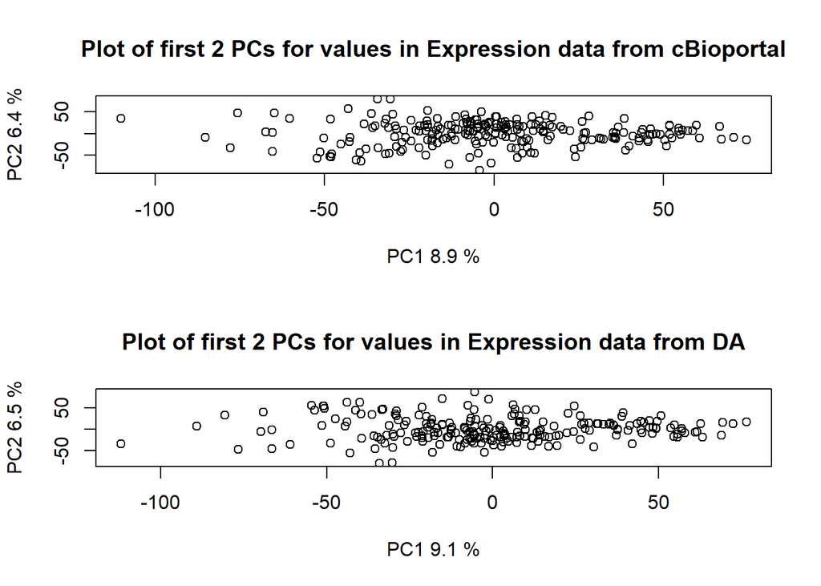

```r
opt<- par(mfrow=c(2,1))
plotPCA2(commonExpressions, scale=TRUE, transpose=TRUE, dataDesc = "Expression data from cBioportal" )
plotPCA2(TCGAExprData, scale=TRUE, transpose=TRUE, dataDesc = "Expression data from DA" )
```

```r
par(opt)
```

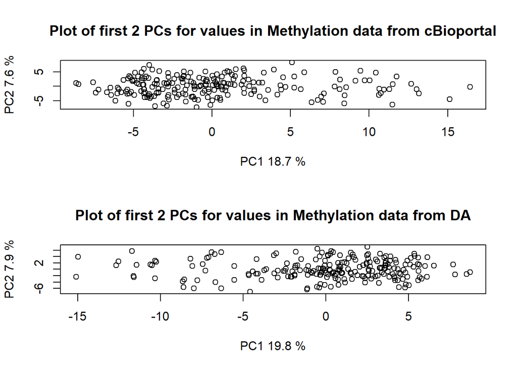

```r
opt<- par(mfrow=c(2,1))
plotPCA2(commonMethylations, scale=FALSE, transpose=TRUE, dataDesc = "Methylation data from cBioportal" )
plotPCA2(TCGAMetilData, scale=FALSE, transpose=TRUE, dataDesc = "Methylation data from DA" )
```

```r
par(opt)
```

The distributions can also be compared using boxplots

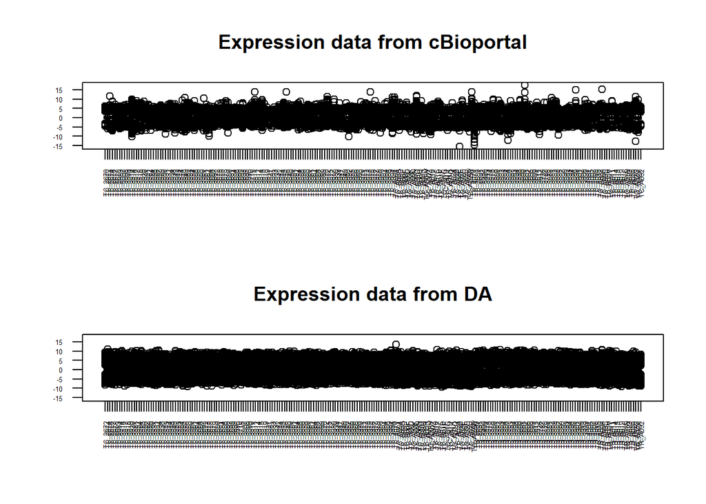

```r
minY<- min(min(commonExpressions),min(TCGAExprData))
maxY <- max(max(commonExpressions),max(TCGAExprData))
opt<- par(mfrow=c(2,1))
boxplot(as.data.frame(commonExpressions), las=2, main = "Expression data from cBioportal", ylim=c(minY, maxY), cex.axis=0.4 )
boxplot(as.data.frame(TCGAExprData), las=2, main  = "Expression data from DA", ylim=c(minY, maxY),  cex.axis=0.4 )
```

```r
par(opt)
```

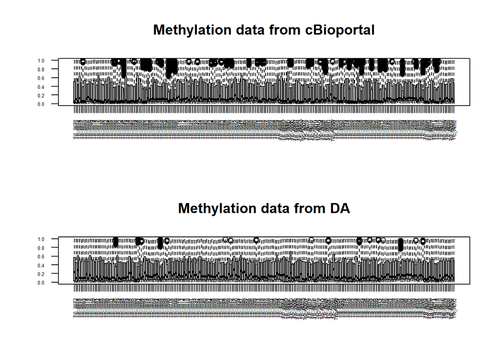

```r
minY<- min(min(commonMethylations),min(TCGAMetilData))
maxY <- max(max(commonMethylations),max(TCGAMetilData))
opt<- par(mfrow=c(2,1))
boxplot(as.data.frame(commonMethylations), las=2, main = "Methylation data from cBioportal", ylim=c(minY, maxY), cex.axis=0.4 )
boxplot(as.data.frame(TCGAMetilData), las=2, main  = "Methylation data from DA", ylim=c(minY, maxY),  cex.axis=0.4 )
```

```r
par(opt)
```

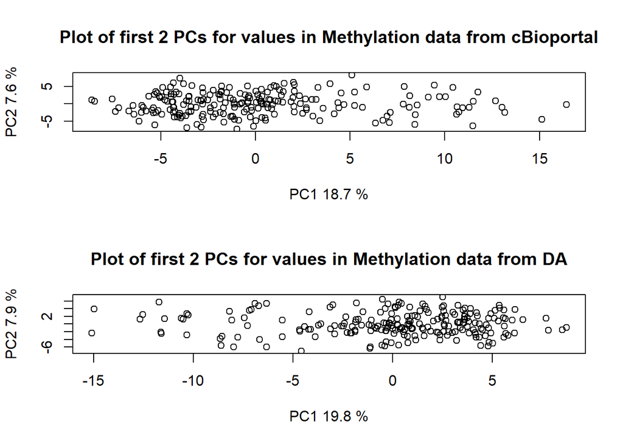

```r
opt<- par(mfrow=c(2,1))
plotPCA2(commonMethylations, scale=FALSE, transpose=TRUE, dataDesc = "Methylation data from cBioportal" )
plotPCA2(TCGAMetilData, scale=FALSE, transpose=TRUE, dataDesc = "Methylation data from DA" )
```

```r
par(opt)
```

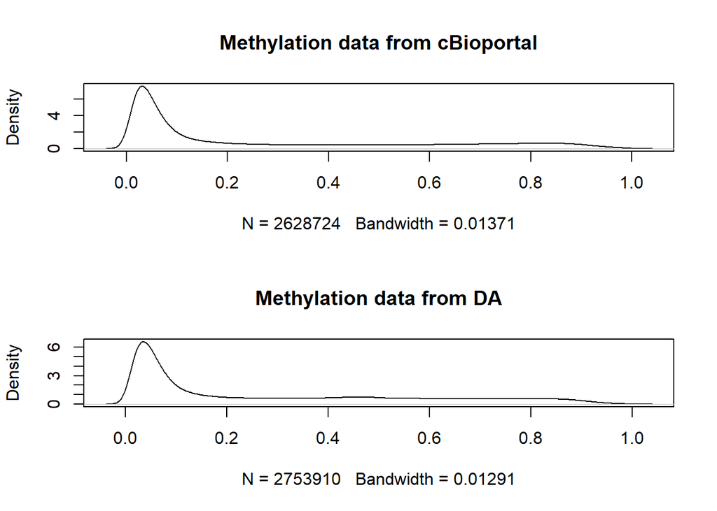

```r
opt<- par(mfrow=c(2,1))
plot(density(commonMethylations), main= "Methylation data from cBioportal" )
plot(density(TCGAMetilData),"Methylation data from DA" )
```

```r
par(opt)
```